# Python Library for Data Science: A Quick Glance

## Introduction

In this lesson we will present the most important python scientific computation libraries used in data analysis. These are libraries of a general nature for analyzing data in Python. In particular we will focus on:

- **Numpy** Numpy is a Python library with math functionalities. It allows us to work with multi-dimensional arrays, matrices, generate random numbers, linear algebra routines, and more.
- **Matplotlib/Seaborn** Matplotlib is a library that allows us to make basic plots, while Seaborn specializes in statistics visualization. The main difference is in the lines of code you need to write to create a plot. Seaborn is easier to learn, has default themes, and makes better-looking plots than Matplotlib by default.
- **Pandas** Pandas is a powerful tool that offers a variety of ways to manipulate and clean data. Pandas work with dataframes that structures data in a table similar to an Excel spreadsheet, but faster and with all the power of Python.

We will reserve a specific study in the course of the other lessons on two extremely important libraries for machine learning applications: scikit-learn and keras.

## Basic NumPy

Numpy (it stands for Numerical Python) is the core library for scientific computing in Python. It provides a high-performance multidimensional array object, and tools for working with these arrays. If you are already familiar with MATLAB, you might find this [tutorial](http://wiki.scipy.org/NumPy_for_Matlab_Users) useful to get started with Numpy. NumPy helps to create arrays (multidimensional arrays), with the help of bindings of C++. Therefore, it is quite fast. There are in-built functions of NumPy as well. It is the fundamental package for scientific computing with Python.

Numpy arrays are collections of things, all of which must be the same type, that work similarly to lists. The most important properties of arrays are:

1. You can easily perform elementwise operations (and matrix algebra) on arrays
2. Arrays can be n-dimensional
3. There is no equivalent to append, although arrays can be concatenated

As we shall see, arrays can be created from existing collections such as lists, or instantiated "from scratch" in a few useful ways.

```python
# We need to import the numpy library to have access to it
# We can also create an alias for a library, this is something you will commonly see with numpy
import numpy as np
```

### Why do we need NumPy?

Does a question arise that why do we need a NumPy array when we have python lists? The answer is we can perform operations on all the elements of a NumPy array at once, which are not possible with python lists. For example, we can’t multiply two lists directly we will have to do it element-wise. This is where the role of NumPy comes into play.

```python
list1 = [2, 4, 6, 7, 8]
list2 = [3, 4, 6, 1, 5]

print(list1*list2)
```

```
---------------------------------------------------------------------------
TypeError                                 Traceback (most recent call last)
Cell In[2], line 4
      1 list1 = [2, 4, 6, 7, 8]
      2 list2 = [3, 4, 6, 1, 5]
----> 4 print(list1*list2)

TypeError: can't multiply sequence by non-int of type 'list'
```

```python
import numpy as np

list1 = [2, 4, 6, 7, 8]
list2 = [3, 4, 6, 1, 5]

arr1 = np.array(list1)
arr2 = np.array(list2)

print(arr1*arr2)
```

[output not shown]

### Arrays

A numpy array is a grid of values, all of the same type, and is indexed by a tuple of nonnegative integers. **The number of dimensions is the rank of the array**; the **shape** of an array is a tuple of integers giving **the size of the array along each dimension**.

```python
a = np.array([1, 2, 3])  # Create a rank 1 array
print(type(a), a.shape, a[0], a[1], a[2])
a[0] = 5                 # Change an element of the array
print(a)
```

[output not shown]

```python
b = np.array([[1,2,3],[4,5,6]])   # Create a rank 2 array
print(b)
print('The dimension of b is : ' + str(b.ndim))
```

```
[[1 2 3]
 [4 5 6]]
The dimension of b is : 2
```

### Array Indexing

Numpy offers several ways to index into arrays.

**Slicing**

Slicing in NumPy means selecting a part of an array instead of the whole thing. It’s like taking a "slice" of a cake 🍰—you only pick the part you want. Similar to Python lists, numpy arrays can be sliced. Since arrays may be multidimensional, you must specify a slice for each dimension of the array:

**IMPORTANT** : A slice of an array is a view into the same data, so modifying it will modify the original array.

```python
a = np.array([[1,2,3,4], [5,6,7,8], [9,10,11,12]])
b = a[:2, 1:3]
print("b submatrix :\n\n", b)
print('\n'+ 100*'-')

print("\n'a' matrix before slicing\n")
print(a)
#
# BEWARE: b[0, 0] is the same piece of data as a[0, 1] !!!
#
b[0, 0] = 77
#
print('\n'+ 100*'-' + "\n\n'a' matrix after slicing\n")
print(a)
```

```
b submatrix :

 [[2 3]
 [6 7]]

----------------------------------------------------------------------------------------------------

'a' matrix before slicing

[[ 1  2  3  4]
 [ 5  6  7  8]
 [ 9 10 11 12]]

----------------------------------------------------------------------------------------------------

'a' matrix after slicing

[[ 1 77  3  4]
 [ 5  6  7  8]
 [ 9 10 11 12]]
```

#### Integer Indexing Vs Slicing

```python
# Create the following rank 2 array with shape (3, 4)
a = np.array([[1,2,3,4], [5,6,7,8], [9,10,11,12]])
print(a)
```

```
[[ 1  2  3  4]
 [ 5  6  7  8]
 [ 9 10 11 12]]
```

**Be Careful!** - Two ways of accessing the data in the middle row of the array. Using integer indexing yields an array of lower rank, while using slicing yields an array of the same rank as the original array:

```python
row_r1 = a[1, :]    # Rank 1 view of the second row of a
row_r2 = a[1:2, :]  # Rank 2 view of the second row of a
print(row_r1, row_r1.shape)
print(row_r2, row_r2.shape)
```

```
[5 6 7 8] (4,)
[[5 6 7 8]] (1, 4)
```

#### Boolean Array Indexing

Boolean array indexing lets you pick out arbitrary elements of an array. Frequently this type of indexing is used to select the elements of an array that satisfy some condition. Here is an example:

```python
import numpy as np

a = np.array([[1,2], [3, 4], [5, 6]])

bool_idx = (a > 2)  # Find the elements of a that are bigger than 2;
                    # this returns a numpy array of Booleans of the same
                    # shape as a, where each slot of bool_idx tells
                    # whether that element of a is > 2.

print(bool_idx)
```

```
[[False False]
 [ True  True]
 [ True  True]]
```

```python
# We use boolean array indexing to construct a rank 1 array
# consisting of the elements of a corresponding to the True values
# of bool_idx
print(a[bool_idx])

# We can do all of the above in a single concise statement:
print(a[a > 2])
```

```
[3 4 5 6]
[3 4 5 6]
```

### Array Math

Basic mathematical functions operate elementwise on arrays, and are available both as operator overloads and as functions in the numpy module:

```python
x = np.array([[1,2],[3,4]], dtype=np.float64)
y = np.array([[5,6],[7,8]], dtype=np.float64)

# Elementwise sum; both produce the array
print(x + y)
print(np.add(x, y))
```

```
[[ 6.  8.]
 [10. 12.]]
[[ 6.  8.]
 [10. 12.]]
```

```python
# Elementwise difference; both produce the array
print(x - y)
print(np.subtract(x, y))
```

```
[[-4. -4.]
 [-4. -4.]]
[[-4. -4.]
 [-4. -4.]]
```

```python
# Elementwise product; both produce the array
print(x * y)
print(np.multiply(x, y))
```

```
[[ 5. 12.]
 [21. 32.]]
[[ 5. 12.]
 [21. 32.]]
```

```python
# Elementwise division; both produce the array
# [[ 0.2         0.33333333]
#  [ 0.42857143  0.5       ]]
print(x / y)
print(np.divide(x, y))
```

```
[[0.2        0.33333333]
 [0.42857143 0.5       ]]
[[0.2        0.33333333]
 [0.42857143 0.5       ]]
```

Note that unlike MATLAB, `*` is elementwise multiplication, not matrix multiplication. We instead use the `dot` function to compute inner products of vectors, to multiply a vector by a matrix, and to multiply matrices. `dot` is available both as a function in the numpy module and as an instance method of array objects:

```python
x = np.array([[1,2],[3,4]])
y = np.array([[5,6],[7,8]])

v = np.array([9,10])
w = np.array([11, 12])

# Inner product of vectors; both produce 219
print(v.dot(w))
print(np.dot(v, w))
```

```
219
219
```

Numpy provides many useful functions for performing computations on arrays; one of the most useful is `sum`:

```python
x = np.array([[1,2],[3,4]])

print(np.sum(x))  # Compute sum of all elements; prints "10"
print(np.sum(x, axis=0))  # Compute sum of each column; prints "[4 6]"
print(np.sum(x, axis=1))  # Compute sum of each row; prints "[3 7]"
```

```
10
[4 6]
[3 7]
```

### NumPy in Data Science & Machine Learning

NumPy is a very popular Python library for large multi-dimensional array and matrix processing. With the help of a large collection of high-level mathematical functions it is very useful for fundamental scientific computations in Machine Learning.

It is particularly useful for,

- Linear Algebra
- Fourier Transform
- Random Number Generations

High-end libraries like TensorFlow uses NumPy internally for manipulation of Tensors.

Lots of ML concepts are tied up with linear algebra. It helps in

- To understand PCA(Principal Component Analysis),
- To build better ML algorithms from scratch,
- For processing Graphics in ML,
- It helps to understand Matrix factorization.

**Example** Calculating the inverse of a matrix

```python
array = np.array([
    [6, 1, 1],
    [4, -2, 5],
    [2, 8, 7]
])

inverse = np.linalg.inv(array)
print(inverse)
```

```
[[ 0.17647059 -0.00326797 -0.02287582]
 [ 0.05882353 -0.13071895  0.08496732]
 [-0.11764706  0.1503268   0.05228758]]
```

**Example** Find eigenvalues and eigenvectors

```python
eigenVal, eigenVec = np.linalg.eig(array)
print(eigenVal)
print(eigenVec)
```

```
[11.24862343  5.09285054 -5.34147398]
[[ 0.24511338  0.75669314  0.02645665]
 [ 0.40622202 -0.03352363 -0.84078293]
 [ 0.88028581 -0.65291014  0.54072554]]
```

**Example** Solve a linear matrix equation

```python
A = np.array([
    [1, 3],
    [2, 4]
])

b = np.array([
    [7],
    [10]
])

x = np.linalg.solve(A, b)
print(x)
```

```
[[1.]
 [2.]]
```

[figure not shown]

## Intro to Matplotlib

**Matplotlib** is a powerful Python library used for creating visualizations and plots. It provides an easy way to generate charts, graphs, and figures for data analysis. The library is widely used in scientific computing, data science, and machine learning to represent data visually.

One of the key advantages of Matplotlib is its simplicity and flexibility. With just a few lines of code, it allows users to create basic plots, while also offering extensive customization options for more complex visualizations. Users can modify colors, labels, line styles, and even create interactive plots.

Matplotlib supports a wide variety of plot types, including line plots, bar charts, histograms, scatter plots, and pie charts. It integrates seamlessly with other Python libraries such as NumPy and Pandas, making it an essential tool for handling and visualizing large datasets. Whether for exploratory data analysis or professional presentations, Matplotlib provides the tools needed to effectively communicate insights through data visualization.

In this section give a brief introduction to the `matplotlib.pyplot` module, which provides a plotting system similar to that of MATLAB.

```python
import matplotlib.pyplot as plt
```

By running this special iPython command, we display plots inline:

```python
%matplotlib inline
```

### Plotting

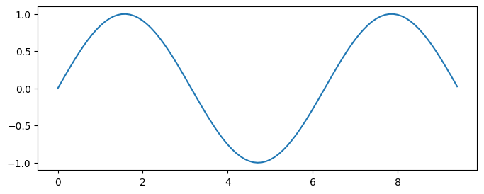

```python
# Compute the x and y coordinates for points on a sine curve
x = np.arange(0, 3 * np.pi, 0.1)
y = np.sin(x)

plt.figure(figsize=(8, 3))  # Set the figure size to 8 inches wide and 6 inches tall

# Plot the points using matplotlib
plt.plot(x, y)
plt.show()
```

With just a little bit of extra work we can easily plot multiple lines at once, and add a title, legend, and axis labels:

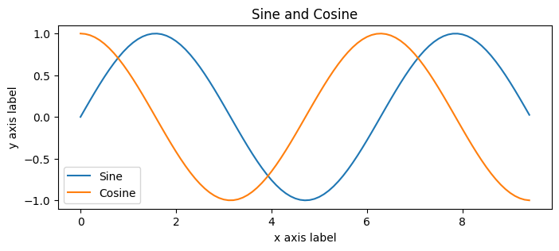

```python
plt.figure(figsize=(8, 3))  # Set the figure size to 8 inches wide and 6 inches tall

y_sin = np.sin(x)
y_cos = np.cos(x)

# Plot the points using matplotlib
plt.plot(x, y_sin)
plt.plot(x, y_cos)
plt.xlabel('x axis label')
plt.ylabel('y axis label')
plt.title('Sine and Cosine')
plt.legend(['Sine', 'Cosine'])
plt.show()
```

### Subplots

```python
# Compute the x and y coordinates for points on sine and cosine curves
x = np.arange(0, 3 * np.pi, 0.1)
y_sin = np.sin(x)
y_cos = np.cos(x)
```

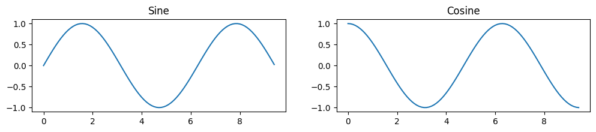

```python
plt.figure(figsize=(12, 2))
# Set up a subplot grid that has height 1 and width 2,
# and set the first such subplot as active.
plt.subplot(1, 2, 1)
# Make the first plot
plt.plot(x, y_sin)
plt.title('Sine')
# Set the second subplot as active, and make the second plot.
plt.subplot(1, 2, 2)
plt.plot(x, y_cos)
plt.title('Cosine')
# Show the figure.
plt.show()
```

[figure not shown]

## Introduction to pandas

The pandas package is probably the most important tool at the disposal of Data Scientists and Analysts working in Python today. The powerful machine learning and glamorous visualization tools may get all the attention, but pandas is the backbone of most data projects. To import pandas we usually import it with a shorter name since it's used so much:

```python
import pandas as pd
```

### Core components of pandas: Series and DataFrames

The primary two components of pandas are the `Series` and `DataFrame`.

A `Series` is essentially a column, and a `DataFrame` is a multi-dimensional table made up of a collection of Series.

[figure not shown]

DataFrames and Series are quite similar in that many operations that you can do with one you can do with the other, such as filling in null values and calculating the mean.

You'll see how these components work when we start working with data below.

### Creating DataFrames from scratch

Creating DataFrames right in Python is good to know and quite useful when testing new methods and functions you find in the pandas docs.

There are *many* ways to create a DataFrame from scratch, a first option is to just use a simple `dict`.

```python
data = {
    'Open'  :[1.20575,1.20566,1.20582,1.20574,1.20596,1.20590],
    'High'  :[1.20576,1.20586,1.20592,1.20601,1.20615,1.20593],
    'Low'   :[1.20560,1.20565,1.20571,1.20569,1.20582,1.20580],
    'Close' :[1.20566,1.20582,1.20572,1.20597,1.20592,1.20588],
    'Volume':[212,88,83,184,246,131]
}
```

[figure not shown]

**Python Pills**

A dictionary in Python is a data structure that stores key-value pairs, allowing fast lookups and efficient data organization. Each key in a dictionary is unique and maps to a specific value, which can be of any data type. Dictionaries are mutable, meaning their contents can be changed after creation. They are commonly used for tasks requiring quick access to data, such as configuration settings, JSON parsing, or counting occurrences of elements in a dataset.

The syntax of a dictionary in Python consists of key-value pairs enclosed in curly braces `{}`. Each key is separated from its corresponding value by a colon `:` and multiple pairs are separated by commas. Keys must be unique and immutable (such as strings, numbers, or tuples), while values can be of any data type. A dictionary is created using `{key: value}` notation or with the `dict()` constructor. For example, `my_dict = {"name": "Alice", "age": 25, "city": "New York"}` defines a dictionary with three key-value pairs.

[figure not shown]

[figure not shown]

```python
fx_eur_usd = pd.DataFrame(data)
fx_eur_usd
```

|  | Open | High | Low | Close | Volume |
| --- | --- | --- | --- | --- | --- |
| 0 | 1.20575 | 1.20576 | 1.20560 | 1.20566 | 212 |
| 1 | 1.20566 | 1.20586 | 1.20565 | 1.20582 | 88 |
| 2 | 1.20582 | 1.20592 | 1.20571 | 1.20572 | 83 |
| 3 | 1.20574 | 1.20601 | 1.20569 | 1.20597 | 184 |
| 4 | 1.20596 | 1.20615 | 1.20582 | 1.20592 | 246 |
| 5 | 1.20590 | 1.20593 | 1.20580 | 1.20588 | 131 |

Let's have time as our index:

```python
fx_eur_usd=pd.DataFrame(data, index=['08/02/2021 15:25', \
                                     '08/02/2021 15:26', \
                                     '08/02/2021 15:27', \
                                     '08/02/2021 15:28', \
                                     '08/02/2021 15:29', \
                                     '08/02/2021 15:30'])
fx_eur_usd
```

|  | Open | High | Low | Close | Volume |
| --- | --- | --- | --- | --- | --- |
| 08/02/2021 15:25 | 1.20575 | 1.20576 | 1.20560 | 1.20566 | 212 |
| 08/02/2021 15:26 | 1.20566 | 1.20586 | 1.20565 | 1.20582 | 88 |
| 08/02/2021 15:27 | 1.20582 | 1.20592 | 1.20571 | 1.20572 | 83 |
| 08/02/2021 15:28 | 1.20574 | 1.20601 | 1.20569 | 1.20597 | 184 |
| 08/02/2021 15:29 | 1.20596 | 1.20615 | 1.20582 | 1.20592 | 246 |
| 08/02/2021 15:30 | 1.20590 | 1.20593 | 1.20580 | 1.20588 | 131 |

So now we could **loc**ate a price by using their time:

```python
fx_eur_usd.loc['08/02/2021 15:27']
```

```
Open       1.20582
High       1.20592
Low        1.20571
Close      1.20572
Volume    83.00000
Name: 08/02/2021 15:27, dtype: float64
```

### How to read in data

It’s quite simple to load data from various file formats into a DataFrame. In the following examples we'll keep using our eur/usd forex data, but this time it's coming from various files.

#### Reading data from CSVs

With CSV files all you need is a single line to load in the data:

```python
df = pd.read_csv(path + 'EURUSD_M1.csv', sep = '\t')
df.head()
```

|  | Time | Open | High | Low | Close | Volume |
| --- | --- | --- | --- | --- | --- | --- |
| 0 | 2019-09-27 04:08:00 | 1.09229 | 1.09229 | 1.09224 | 1.09227 | 23 |
| 1 | 2019-09-27 04:09:00 | 1.09227 | 1.09228 | 1.09224 | 1.09228 | 70 |
| 2 | 2019-09-27 04:10:00 | 1.09228 | 1.09230 | 1.09226 | 1.09227 | 28 |
| 3 | 2019-09-27 04:11:00 | 1.09226 | 1.09240 | 1.09226 | 1.09234 | 164 |
| 4 | 2019-09-27 04:12:00 | 1.09234 | 1.09240 | 1.09234 | 1.09239 | 61 |

```python
df = pd.read_csv(path + 'EURUSD_M1.csv', sep = '\t', index_col=0)
df.head()
```

| Time | Open | High | Low | Close | Volume |
| --- | --- | --- | --- | --- | --- |
| 2019-09-27 04:08:00 | 1.09229 | 1.09229 | 1.09224 | 1.09227 | 23 |
| 2019-09-27 04:09:00 | 1.09227 | 1.09228 | 1.09224 | 1.09228 | 70 |
| 2019-09-27 04:10:00 | 1.09228 | 1.09230 | 1.09226 | 1.09227 | 28 |
| 2019-09-27 04:11:00 | 1.09226 | 1.09240 | 1.09226 | 1.09234 | 164 |
| 2019-09-27 04:12:00 | 1.09234 | 1.09240 | 1.09234 | 1.09239 | 61 |

### Most important DataFrame operations

DataFrames possess hundreds of methods and other operations that are crucial to any analysis. As a beginner, you should know the operations that perform simple transformations of your data and those that provide fundamental statistical analysis.

Let's load in the IMDB movies dataset to begin. The IMDB movies dataset is a collection of movie-related data extracted from the IMDB website. It typically includes details such as movie titles, release years, ratings, genres, cast and crew information, runtimes, and vote counts. This dataset is commonly used for analyzing trends in the film industry, exploring audience preferences, and performing statistical analysis or visualizations related to movie performance and characteristics.

```python
movies_df = pd.read_csv(path + "IMDB-Movie-Data.csv", index_col="Title")
```

#### Viewing your data

The first thing to do when opening a new dataset is print out a few rows to keep as a visual reference. We accomplish this with `.head()`:

```python
movies_df.head()
```

| Title | Rank | Genre | Description | Director | Actors | Year | Runtime (Minutes) | Rating | Votes | Revenue (Millions) | Metascore |
| --- | --- | --- | --- | --- | --- | --- | --- | --- | --- | --- | --- |
| Guardians of the Galaxy | 1 | Action,Adventure,Sci-Fi | A group of intergalactic criminals are forced ... | James Gunn | Chris Pratt, Vin Diesel, Bradley Cooper, Zoe S... | 2014 | 121 | 8.1 | 757074 | 333.13 | 76.0 |
| Prometheus | 2 | Adventure,Mystery,Sci-Fi | Following clues to the origin of mankind, a te... | Ridley Scott | Noomi Rapace, Logan Marshall-Green, Michael Fa... | 2012 | 124 | 7.0 | 485820 | 126.46 | 65.0 |
| Split | 3 | Horror,Thriller | Three girls are kidnapped by a man with a diag... | M. Night Shyamalan | James McAvoy, Anya Taylor-Joy, Haley Lu Richar... | 2016 | 117 | 7.3 | 157606 | 138.12 | 62.0 |
| Sing | 4 | Animation,Comedy,Family | In a city of humanoid animals, a hustling thea... | Christophe Lourdelet | Matthew McConaughey,Reese Witherspoon, Seth Ma... | 2016 | 108 | 7.2 | 60545 | 270.32 | 59.0 |
| Suicide Squad | 5 | Action,Adventure,Fantasy | A secret government agency recruits some of th... | David Ayer | Will Smith, Jared Leto, Margot Robbie, Viola D... | 2016 | 123 | 6.2 | 393727 | 325.02 | 40.0 |

#### Getting info about your data

`.info()` should be one of the very first commands you run after loading your data:

```python
movies_df.info()
```

```
<class 'pandas.core.frame.DataFrame'>
Index: 1000 entries, Guardians of the Galaxy to Nine Lives
Data columns (total 11 columns):
 #   Column              Non-Null Count  Dtype
---  ------              --------------  -----
 0   Rank                1000 non-null   int64
 1   Genre               1000 non-null   object
 2   Description         1000 non-null   object
 3   Director            1000 non-null   object
 4   Actors              1000 non-null   object
 5   Year                1000 non-null   int64
 6   Runtime (Minutes)   1000 non-null   int64
 7   Rating              1000 non-null   float64
 8   Votes               1000 non-null   int64
 9   Revenue (Millions)  872 non-null    float64
 10  Metascore           936 non-null    float64
dtypes: float64(3), int64(4), object(4)
memory usage: 93.8+ KB
```

#### Handling duplicates

We will have an entire lesson (or almost) on the problems of preliminary data analysis (data cleaning, missing values, etc). But let's start immediately by seeing how to use the potential of pandas to carry out rapid data cleaning....

This dataset does not have duplicate rows, but it is always important to verify you aren't aggregating duplicate rows. To demonstrate, let's simply just double up our movies DataFrame by appending it to itself:

```python
temp_df = pd.concat([movies_df, movies_df], ignore_index=True)

temp_df.shape
```

```
(2000, 11)
```

```python
temp_df = temp_df.drop_duplicates()

temp_df.shape
```

```
(1000, 11)
```

It's a little verbose to keep assigning DataFrames to the same variable like in this example. For this reason, pandas has the `inplace` keyword argument on many of its methods. Using `inplace=True` will modify the DataFrame object in place:

```python
temp_df.drop_duplicates(inplace=True)
```

#### Column cleanup

Many times datasets will have verbose column names with symbols, upper and lowercase words, spaces, and typos. To make selecting data by column name easier we can spend a little time cleaning up their names.

Here's how to print the column names of our dataset:

```python
movies_df.columns
```

```
Index(['Rank', 'Genre', 'Description', 'Director', 'Actors', 'Year',
       'Runtime (Minutes)', 'Rating', 'Votes', 'Revenue (Millions)',
       'Metascore'],
      dtype='object')
```

Not only does `.columns` come in handy if you want to rename columns by allowing for simple copy and paste, it's also useful if you need to understand why you are receiving a `Key Error` when selecting data by column.

We can use the `.rename()` method to rename certain or all columns via a `dict`. We don't want parentheses, so let's rename those:

```python
movies_df.rename(columns={
        'Runtime (Minutes)': 'Runtime',
        'Revenue (Millions)': 'Revenue_millions'
    }, inplace=True)


movies_df.columns
```

```
Index(['Rank', 'Genre', 'Description', 'Director', 'Actors', 'Year', 'Runtime',
       'Rating', 'Votes', 'Revenue_millions', 'Metascore'],
      dtype='object')
```

But what if we want to lowercase all names? Instead of using `.rename()` we could also set a list of names to the columns like so:

```python
movies_df.columns = ['rank', 'genre', 'description', 'director', 'actors', 'year', 'runtime',
                     'rating', 'votes', 'revenue_millions', 'metascore']


movies_df.columns
```

```
Index(['rank', 'genre', 'description', 'director', 'actors', 'year', 'runtime',
       'rating', 'votes', 'revenue_millions', 'metascore'],
      dtype='object')
```

But that's too much work. Instead of just renaming each column manually we can do a list comprehension:

```python
movies_df.columns = [col.lower() for col in movies_df]

movies_df.columns
```

```
Index(['rank', 'genre', 'description', 'director', 'actors', 'year', 'runtime',
       'rating', 'votes', 'revenue_millions', 'metascore'],
      dtype='object')
```

[figure not shown]

**Python Pills**

List comprehension in Python is a concise way to create lists by applying an expression to each item in an iterable, all in a single line of code. It simplifies code and often makes it more readable.

For example, to create a list of squares for numbers 0 through 4:

```
squares = [x**2 for x in range(5)]
print(squares)  # Output: [0, 1, 4, 9, 16]
```

### How to work with missing values

When exploring data, you’ll most likely encounter missing or null values, which are essentially placeholders for non-existent values. Most commonly you'll see Python's `None` or NumPy's `np.nan`, each of which are handled differently in some situations.

There are two options in dealing with nulls:

1. Get rid of rows or columns with nulls
2. Replace nulls with non-null values, a technique known as **imputation**

Let's calculate to total number of nulls in each column of our dataset. The first step is to check which cells in our DataFrame are null:

```python
movies_df.isnull()
```

| Title | rank | genre | description | director | actors | year | runtime | rating | votes | revenue_millions | metascore |
| --- | --- | --- | --- | --- | --- | --- | --- | --- | --- | --- | --- |
| Guardians of the Galaxy | False | False | False | False | False | False | False | False | False | False | False |
| Prometheus | False | False | False | False | False | False | False | False | False | False | False |
| Split | False | False | False | False | False | False | False | False | False | False | False |
| Sing | False | False | False | False | False | False | False | False | False | False | False |
| Suicide Squad | False | False | False | False | False | False | False | False | False | False | False |
| ... | ... | ... | ... | ... | ... | ... | ... | ... | ... | ... | ... |
| Secret in Their Eyes | False | False | False | False | False | False | False | False | False | True | False |
| Hostel: Part II | False | False | False | False | False | False | False | False | False | False | False |
| Step Up 2: The Streets | False | False | False | False | False | False | False | False | False | False | False |
| Search Party | False | False | False | False | False | False | False | False | False | True | False |
| Nine Lives | False | False | False | False | False | False | False | False | False | False | False |

1000 rows × 11 columns

Notice `isnull()` returns a DataFrame where each cell is either True or False depending on that cell's null status.

To count the number of nulls in each column we use an aggregate function for summing:

```python
movies_df.isnull().sum()
```

```
rank                  0
genre                 0
description           0
director              0
actors                0
year                  0
runtime               0
rating                0
votes                 0
revenue_millions    128
metascore            64
dtype: int64
```

#### Removing null values

Data Scientists and Analysts regularly face the dilemma of dropping or imputing null values, and is a decision that requires intimate knowledge of your data and its context. Overall, removing null data is only suggested if you have a small amount of missing data.

Remove nulls is pretty simple:

```python
movies_df.dropna().head()
```

| Title | rank | genre | description | director | actors | year | runtime | rating | votes | revenue_millions | metascore |
| --- | --- | --- | --- | --- | --- | --- | --- | --- | --- | --- | --- |
| Guardians of the Galaxy | 1 | Action,Adventure,Sci-Fi | A group of intergalactic criminals are forced ... | James Gunn | Chris Pratt, Vin Diesel, Bradley Cooper, Zoe S... | 2014 | 121 | 8.1 | 757074 | 333.13 | 76.0 |
| Prometheus | 2 | Adventure,Mystery,Sci-Fi | Following clues to the origin of mankind, a te... | Ridley Scott | Noomi Rapace, Logan Marshall-Green, Michael Fa... | 2012 | 124 | 7.0 | 485820 | 126.46 | 65.0 |
| Split | 3 | Horror,Thriller | Three girls are kidnapped by a man with a diag... | M. Night Shyamalan | James McAvoy, Anya Taylor-Joy, Haley Lu Richar... | 2016 | 117 | 7.3 | 157606 | 138.12 | 62.0 |
| Sing | 4 | Animation,Comedy,Family | In a city of humanoid animals, a hustling thea... | Christophe Lourdelet | Matthew McConaughey,Reese Witherspoon, Seth Ma... | 2016 | 108 | 7.2 | 60545 | 270.32 | 59.0 |
| Suicide Squad | 5 | Action,Adventure,Fantasy | A secret government agency recruits some of th... | David Ayer | Will Smith, Jared Leto, Margot Robbie, Viola D... | 2016 | 123 | 6.2 | 393727 | 325.02 | 40.0 |

This operation will delete any **row** with at least a single null value, but it will return a new DataFrame without altering the original one. You could specify `inplace=True` in this method as well.

So in the case of our dataset, this operation would remove 128 rows where `revenue_millions` is null and 64 rows where `metascore` is null. This obviously seems like a waste since there's perfectly good data in the other columns of those dropped rows. That's why we'll look at **imputation** next.

Other than just dropping rows, you can also drop columns with null values by setting `axis=1`:

```python
movies_df.dropna(axis=1).head()
```

| Title | rank | genre | description | director | actors | year | runtime | rating | votes |
| --- | --- | --- | --- | --- | --- | --- | --- | --- | --- |
| Guardians of the Galaxy | 1 | Action,Adventure,Sci-Fi | A group of intergalactic criminals are forced ... | James Gunn | Chris Pratt, Vin Diesel, Bradley Cooper, Zoe S... | 2014 | 121 | 8.1 | 757074 |
| Prometheus | 2 | Adventure,Mystery,Sci-Fi | Following clues to the origin of mankind, a te... | Ridley Scott | Noomi Rapace, Logan Marshall-Green, Michael Fa... | 2012 | 124 | 7.0 | 485820 |
| Split | 3 | Horror,Thriller | Three girls are kidnapped by a man with a diag... | M. Night Shyamalan | James McAvoy, Anya Taylor-Joy, Haley Lu Richar... | 2016 | 117 | 7.3 | 157606 |
| Sing | 4 | Animation,Comedy,Family | In a city of humanoid animals, a hustling thea... | Christophe Lourdelet | Matthew McConaughey,Reese Witherspoon, Seth Ma... | 2016 | 108 | 7.2 | 60545 |
| Suicide Squad | 5 | Action,Adventure,Fantasy | A secret government agency recruits some of th... | David Ayer | Will Smith, Jared Leto, Margot Robbie, Viola D... | 2016 | 123 | 6.2 | 393727 |

### Imputation

**Imputation** is a conventional feature engineering technique used to keep valuable data that have null values.

There may be instances where dropping every row with a null value removes too big a chunk from your dataset, so instead we can impute that null with another value, usually the **mean** or the **median** of that column.

Let's look at imputing the missing values in the `revenue_millions` column. First we'll extract that column into its own variable:

```python
revenue = movies_df['revenue_millions']
```

**Using square brackets is the general way we select columns in a DataFrame**.

If you remember back to when we created DataFrames from scratch, the keys of the `dict` ended up as column names. Now when we select columns of a DataFrame, we use brackets just like if we were accessing a Python dictionary.

`revenue` now contains a Series:

```python
revenue.head()
```

```
Title
Guardians of the Galaxy    333.13
Prometheus                 126.46
Split                      138.12
Sing                       270.32
Suicide Squad              325.02
Name: revenue_millions, dtype: float64
```

```python
revenue_mean = revenue.mean()

revenue_mean
```

```
82.95637614678898
```

With the mean, let's fill the nulls using `fillna()`:

```python
revenue.fillna(revenue_mean, inplace=True)
```

```python
movies_df.isnull().sum()
```

```
rank                 0
genre                0
description          0
director             0
actors               0
year                 0
runtime              0
rating               0
votes                0
revenue_millions     0
metascore           64
dtype: int64
```

### Understanding your variables

Using `describe()` on an entire DataFrame we can get a summary of the distribution of **continuous** variables:

```python
movies_df.describe().head()
```

|  | rank | year | runtime | rating | votes | revenue_millions | metascore |
| --- | --- | --- | --- | --- | --- | --- | --- |
| count | 1000.000000 | 1000.000000 | 1000.000000 | 1000.000000 | 1000.000000 | 1000.000000 | 936.000000 |
| mean | 500.500000 | 2012.783000 | 113.172000 | 6.723200 | 169808.255000 | 82.956376 | 58.985043 |
| std | 288.819436 | 3.205962 | 18.810908 | 0.945429 | 188762.647518 | 96.412043 | 17.194757 |
| min | 1.000000 | 2006.000000 | 66.000000 | 1.900000 | 61.000000 | 0.000000 | 11.000000 |
| 25% | 250.750000 | 2010.000000 | 100.000000 | 6.200000 | 36309.000000 | 17.442500 | 47.000000 |

Understanding which numbers are continuous also comes in handy when thinking about the type of plot to use to represent your data visually.

`.describe()` can also be used on a categorical variable to get the count of rows, unique count of categories, top category, and freq of top category:

```python
movies_df['genre'].describe()
```

```
count                        1000
unique                        207
top       Action,Adventure,Sci-Fi
freq                           50
Name: genre, dtype: object
```

This tells us that the genre column has 207 unique values, the top value is Action/Adventure/Sci-Fi, which shows up 50 times (freq).

`.value_counts()` can tell us the frequency of all values in a column:

```python
movies_df['genre'].value_counts().head(10)
```

```
genre
Action,Adventure,Sci-Fi       50
Drama                         48
Comedy,Drama,Romance          35
Comedy                        32
Drama,Romance                 31
Animation,Adventure,Comedy    27
Action,Adventure,Fantasy      27
Comedy,Drama                  27
Comedy,Romance                26
Crime,Drama,Thriller          24
Name: count, dtype: int64
```

#### Relationships between continuous variables

By using the correlation method `.corr()` we can generate the relationship between each continuous variable:

```python
# Select only the numerical features for correlation analysis
numerical_features = movies_df.select_dtypes(include=np.number)

# Calculate the correlation matrix
correlation_matrix = numerical_features.corr()

# Display the correlation matrix
print(correlation_matrix)
```

```
                      rank      year   runtime    rating     votes  \
rank              1.000000 -0.261605 -0.221739 -0.219555 -0.283876
year             -0.261605  1.000000 -0.164900 -0.211219 -0.411904
runtime          -0.221739 -0.164900  1.000000  0.392214  0.407062
rating           -0.219555 -0.211219  0.392214  1.000000  0.511537
votes            -0.283876 -0.411904  0.407062  0.511537  1.000000
revenue_millions -0.252996 -0.117562  0.247834  0.189527  0.607941
metascore        -0.191869 -0.079305  0.211978  0.631897  0.325684

                  revenue_millions  metascore
rank                     -0.252996  -0.191869
year                     -0.117562  -0.079305
runtime                   0.247834   0.211978
rating                    0.189527   0.631897
votes                     0.607941   0.325684
revenue_millions          1.000000   0.133328
metascore                 0.133328   1.000000
```

### DataFrame slicing, selecting, extracting

Up until now we've focused on some basic summaries of our data. We've learned about simple column extraction using single brackets, and we imputed null values in a column using `fillna()`. Below are the other methods of slicing, selecting, and extracting you'll need to use constantly.

It's important to note that, although many methods are the same, DataFrames and Series have different attributes, so you'll need be sure to know which type you are working with or else you will receive attribute errors.

Let's look at working with columns first.

#### By column

You already saw how to extract a column using square brackets like this:

```python
genre_col = movies_df['genre']

type(genre_col)
```

```
pandas.core.series.Series
```

This will return a *Series*. To extract a column as a *DataFrame*, you need to pass a list of column names. In our case that's just a single column:

```python
genre_col = movies_df[['genre']]

type(genre_col)
```

```
pandas.core.frame.DataFrame
```

Since it's just a list, adding another column name is easy:

```python
subset = movies_df[['genre', 'rating']]

subset.head()
```

| Title | genre | rating |
| --- | --- | --- |
| Guardians of the Galaxy | Action,Adventure,Sci-Fi | 8.1 |
| Prometheus | Adventure,Mystery,Sci-Fi | 7.0 |
| Split | Horror,Thriller | 7.3 |
| Sing | Animation,Comedy,Family | 7.2 |
| Suicide Squad | Action,Adventure,Fantasy | 6.2 |

#### By rows

For rows, we have two options:

- `.loc` - **loc**ates by name
- `.iloc`- **loc**ates by numerical **i**ndex

Remember that we are still indexed by movie Title, so to use `.loc` we give it the Title of a movie:

```python
prom = movies_df.loc["Prometheus"]
prom
```

```
rank                                                                2
genre                                        Adventure,Mystery,Sci-Fi
description         Following clues to the origin of mankind, a te...
director                                                 Ridley Scott
actors              Noomi Rapace, Logan Marshall-Green, Michael Fa...
year                                                             2012
runtime                                                           124
rating                                                            7.0
votes                                                          485820
revenue_millions                                               126.46
metascore                                                        65.0
Name: Prometheus, dtype: object
```

On the other hand, with `iloc` we give it the numerical index of Prometheus:

```python
prom = movies_df.iloc[1]
prom
```

```
rank                                                                2
genre                                        Adventure,Mystery,Sci-Fi
description         Following clues to the origin of mankind, a te...
director                                                 Ridley Scott
actors              Noomi Rapace, Logan Marshall-Green, Michael Fa...
year                                                             2012
runtime                                                           124
rating                                                            7.0
votes                                                          485820
revenue_millions                                               126.46
metascore                                                        65.0
Name: Prometheus, dtype: object
```

`loc` and `iloc` can be thought of as similar to Python `list` slicing. To show this even further, let's select multiple rows.

How would you do it with a list? In Python, just slice with brackets like `example_list[1:4]`. It's works the same way in pandas:

```python
movie_subset = movies_df.loc['Prometheus':'Sing']
movie_subset
```

| Title | rank | genre | description | director | actors | year | runtime | rating | votes | revenue_millions | metascore |
| --- | --- | --- | --- | --- | --- | --- | --- | --- | --- | --- | --- |
| Prometheus | 2 | Adventure,Mystery,Sci-Fi | Following clues to the origin of mankind, a te... | Ridley Scott | Noomi Rapace, Logan Marshall-Green, Michael Fa... | 2012 | 124 | 7.0 | 485820 | 126.46 | 65.0 |
| Split | 3 | Horror,Thriller | Three girls are kidnapped by a man with a diag... | M. Night Shyamalan | James McAvoy, Anya Taylor-Joy, Haley Lu Richar... | 2016 | 117 | 7.3 | 157606 | 138.12 | 62.0 |
| Sing | 4 | Animation,Comedy,Family | In a city of humanoid animals, a hustling thea... | Christophe Lourdelet | Matthew McConaughey,Reese Witherspoon, Seth Ma... | 2016 | 108 | 7.2 | 60545 | 270.32 | 59.0 |

```python
movie_subset = movies_df.iloc[1:4]
movie_subset
```

| Title | rank | genre | description | director | actors | year | runtime | rating | votes | revenue_millions | metascore |
| --- | --- | --- | --- | --- | --- | --- | --- | --- | --- | --- | --- |
| Prometheus | 2 | Adventure,Mystery,Sci-Fi | Following clues to the origin of mankind, a te... | Ridley Scott | Noomi Rapace, Logan Marshall-Green, Michael Fa... | 2012 | 124 | 7.0 | 485820 | 126.46 | 65.0 |
| Split | 3 | Horror,Thriller | Three girls are kidnapped by a man with a diag... | M. Night Shyamalan | James McAvoy, Anya Taylor-Joy, Haley Lu Richar... | 2016 | 117 | 7.3 | 157606 | 138.12 | 62.0 |
| Sing | 4 | Animation,Comedy,Family | In a city of humanoid animals, a hustling thea... | Christophe Lourdelet | Matthew McConaughey,Reese Witherspoon, Seth Ma... | 2016 | 108 | 7.2 | 60545 | 270.32 | 59.0 |

#### Conditional selections

We’ve gone over how to select columns and rows, but what if we want to make a conditional selection? For example, what if we want to filter our movies DataFrame to show **only films directed by Ridley Scott** or **films with a rating greater than or equal to 8.0**? To do that, we take a column from the DataFrame and apply a **boolean condition** to it. Here's an example of a Boolean condition:

```python
condition = (movies_df['director'] == "Ridley Scott")
condition.head()
```

```
Title
Guardians of the Galaxy    False
Prometheus                  True
Split                      False
Sing                       False
Suicide Squad              False
Name: director, dtype: bool
```

Similar to `isnull()`, this returns a Series of True and False values: True for films directed by Ridley Scott and False for ones not directed by him.

We want to filter out all movies not directed by Ridley Scott, in other words, we don’t want the False films. To return the rows where that condition is True we have to pass this operation into the DataFrame:

```python
movies_df[movies_df['director'] == "Ridley Scott"].head()
```

| Title | rank | genre | description | director | actors | year | runtime | rating | votes | revenue_millions | metascore |
| --- | --- | --- | --- | --- | --- | --- | --- | --- | --- | --- | --- |
| Prometheus | 2 | Adventure,Mystery,Sci-Fi | Following clues to the origin of mankind, a te... | Ridley Scott | Noomi Rapace, Logan Marshall-Green, Michael Fa... | 2012 | 124 | 7.0 | 485820 | 126.46 | 65.0 |
| The Martian | 103 | Adventure,Drama,Sci-Fi | An astronaut becomes stranded on Mars after hi... | Ridley Scott | Matt Damon, Jessica Chastain, Kristen Wiig, Ka... | 2015 | 144 | 8.0 | 556097 | 228.43 | 80.0 |
| Robin Hood | 388 | Action,Adventure,Drama | In 12th century England, Robin and his band of... | Ridley Scott | Russell Crowe, Cate Blanchett, Matthew Macfady... | 2010 | 140 | 6.7 | 221117 | 105.22 | 53.0 |
| American Gangster | 471 | Biography,Crime,Drama | In 1970s America, a detective works to bring d... | Ridley Scott | Denzel Washington, Russell Crowe, Chiwetel Eji... | 2007 | 157 | 7.8 | 337835 | 130.13 | 76.0 |
| Exodus: Gods and Kings | 517 | Action,Adventure,Drama | The defiant leader Moses rises up against the ... | Ridley Scott | Christian Bale, Joel Edgerton, Ben Kingsley, S... | 2014 | 150 | 6.0 | 137299 | 65.01 | 52.0 |

You can get used to looking at these conditionals by reading it like:

> **SELECT * FROM movies_df WHERE movies_df.director = 'Ridley Scott'**

Let's look at conditional selections using numerical values by filtering the DataFrame by ratings:

```python
movies_df[movies_df['rating'] >= 8.6].head(3)
```

| Title | rank | genre | description | director | actors | year | runtime | rating | votes | revenue_millions | metascore |
| --- | --- | --- | --- | --- | --- | --- | --- | --- | --- | --- | --- |
| Interstellar | 37 | Adventure,Drama,Sci-Fi | A team of explorers travel through a wormhole ... | Christopher Nolan | Matthew McConaughey, Anne Hathaway, Jessica Ch... | 2014 | 169 | 8.6 | 1047747 | 187.99 | 74.0 |
| The Dark Knight | 55 | Action,Crime,Drama | When the menace known as the Joker wreaks havo... | Christopher Nolan | Christian Bale, Heath Ledger, Aaron Eckhart,Mi... | 2008 | 152 | 9.0 | 1791916 | 533.32 | 82.0 |
| Inception | 81 | Action,Adventure,Sci-Fi | A thief, who steals corporate secrets through ... | Christopher Nolan | Leonardo DiCaprio, Joseph Gordon-Levitt, Ellen... | 2010 | 148 | 8.8 | 1583625 | 292.57 | 74.0 |

We can make some richer conditionals by using logical operators `|` for "or" and `&` for "and".

Let's filter the the DataFrame to show only movies by Christopher Nolan OR Ridley Scott:

```python
movies_df[(movies_df['director'] == 'Christopher Nolan') | (movies_df['director'] == 'Ridley Scott')].head()
```

| Title | rank | genre | description | director | actors | year | runtime | rating | votes | revenue_millions | metascore |
| --- | --- | --- | --- | --- | --- | --- | --- | --- | --- | --- | --- |
| Prometheus | 2 | Adventure,Mystery,Sci-Fi | Following clues to the origin of mankind, a te... | Ridley Scott | Noomi Rapace, Logan Marshall-Green, Michael Fa... | 2012 | 124 | 7.0 | 485820 | 126.46 | 65.0 |
| Interstellar | 37 | Adventure,Drama,Sci-Fi | A team of explorers travel through a wormhole ... | Christopher Nolan | Matthew McConaughey, Anne Hathaway, Jessica Ch... | 2014 | 169 | 8.6 | 1047747 | 187.99 | 74.0 |
| The Dark Knight | 55 | Action,Crime,Drama | When the menace known as the Joker wreaks havo... | Christopher Nolan | Christian Bale, Heath Ledger, Aaron Eckhart,Mi... | 2008 | 152 | 9.0 | 1791916 | 533.32 | 82.0 |
| The Prestige | 65 | Drama,Mystery,Sci-Fi | Two stage magicians engage in competitive one-... | Christopher Nolan | Christian Bale, Hugh Jackman, Scarlett Johanss... | 2006 | 130 | 8.5 | 913152 | 53.08 | 66.0 |
| Inception | 81 | Action,Adventure,Sci-Fi | A thief, who steals corporate secrets through ... | Christopher Nolan | Leonardo DiCaprio, Joseph Gordon-Levitt, Ellen... | 2010 | 148 | 8.8 | 1583625 | 292.57 | 74.0 |

We need to make sure to group evaluations with parentheses so Python knows how to evaluate the conditional.

Using the `isin()` method we could make this more concise though:

```python
movies_df[movies_df['director'].isin(['Christopher Nolan', 'Ridley Scott'])].head()
```

| Title | rank | genre | description | director | actors | year | runtime | rating | votes | revenue_millions | metascore |
| --- | --- | --- | --- | --- | --- | --- | --- | --- | --- | --- | --- |
| Prometheus | 2 | Adventure,Mystery,Sci-Fi | Following clues to the origin of mankind, a te... | Ridley Scott | Noomi Rapace, Logan Marshall-Green, Michael Fa... | 2012 | 124 | 7.0 | 485820 | 126.46 | 65.0 |
| Interstellar | 37 | Adventure,Drama,Sci-Fi | A team of explorers travel through a wormhole ... | Christopher Nolan | Matthew McConaughey, Anne Hathaway, Jessica Ch... | 2014 | 169 | 8.6 | 1047747 | 187.99 | 74.0 |
| The Dark Knight | 55 | Action,Crime,Drama | When the menace known as the Joker wreaks havo... | Christopher Nolan | Christian Bale, Heath Ledger, Aaron Eckhart,Mi... | 2008 | 152 | 9.0 | 1791916 | 533.32 | 82.0 |
| The Prestige | 65 | Drama,Mystery,Sci-Fi | Two stage magicians engage in competitive one-... | Christopher Nolan | Christian Bale, Hugh Jackman, Scarlett Johanss... | 2006 | 130 | 8.5 | 913152 | 53.08 | 66.0 |
| Inception | 81 | Action,Adventure,Sci-Fi | A thief, who steals corporate secrets through ... | Christopher Nolan | Leonardo DiCaprio, Joseph Gordon-Levitt, Ellen... | 2010 | 148 | 8.8 | 1583625 | 292.57 | 74.0 |

Let's say we want all movies that were released between 2005 and 2010, have a rating above 8.0, but made below the 25th percentile in revenue.

Here's how we could do all of that:

```python
movies_df[
    ((movies_df['year'] >= 2005) & (movies_df['year'] <= 2010))
    & (movies_df['rating'] > 8.0)
    & (movies_df['revenue_millions'] < movies_df['revenue_millions'].quantile(0.25))
]
```

| Title | rank | genre | description | director | actors | year | runtime | rating | votes | revenue_millions | metascore |
| --- | --- | --- | --- | --- | --- | --- | --- | --- | --- | --- | --- |
| 3 Idiots | 431 | Comedy,Drama | Two friends are searching for their long lost ... | Rajkumar Hirani | Aamir Khan, Madhavan, Mona Singh, Sharman Joshi | 2009 | 170 | 8.4 | 238789 | 6.52 | 67.0 |
| The Lives of Others | 477 | Drama,Thriller | In 1984 East Berlin, an agent of the secret po... | Florian Henckel von Donnersmarck | Ulrich Mühe, Martina Gedeck,Sebastian Koch, Ul... | 2006 | 137 | 8.5 | 278103 | 11.28 | 89.0 |
| Incendies | 714 | Drama,Mystery,War | Twins journey to the Middle East to discover t... | Denis Villeneuve | Lubna Azabal, Mélissa Désormeaux-Poulin, Maxim... | 2010 | 131 | 8.2 | 92863 | 6.86 | 80.0 |
| Taare Zameen Par | 992 | Drama,Family,Music | An eight-year-old boy is thought to be a lazy ... | Aamir Khan | Darsheel Safary, Aamir Khan, Tanay Chheda, Sac... | 2007 | 165 | 8.5 | 102697 | 1.20 | 42.0 |

### Applying functions

It is possible to iterate over a DataFrame or Series as you would with a list, but doing so — especially on large datasets — is very slow.

An efficient alternative is to `apply()` a function to the dataset. For example, we could use a function to convert movies with an 8.0 or greater to a string value of "good" and the rest to "bad" and use this transformed values to create a new column.

First we would create a function that, when given a rating, determines if it's good or bad:

```python
def rating_function(x):
    if x >= 8.0:
        return "good"
    else:
        return "bad"
```

Now we want to send the entire rating column through this function, which is what `apply()` does:

```python
movies_df["rating_category"] = movies_df["rating"].apply(rating_function)

movies_df.head(2)
```

| Title | rank | genre | description | director | actors | year | runtime | rating | votes | revenue_millions | metascore | rating_category |
| --- | --- | --- | --- | --- | --- | --- | --- | --- | --- | --- | --- | --- |
| Guardians of the Galaxy | 1 | Action,Adventure,Sci-Fi | A group of intergalactic criminals are forced ... | James Gunn | Chris Pratt, Vin Diesel, Bradley Cooper, Zoe S... | 2014 | 121 | 8.1 | 757074 | 333.13 | 76.0 | good |
| Prometheus | 2 | Adventure,Mystery,Sci-Fi | Following clues to the origin of mankind, a te... | Ridley Scott | Noomi Rapace, Logan Marshall-Green, Michael Fa... | 2012 | 124 | 7.0 | 485820 | 126.46 | 65.0 | bad |

The `.apply()` method passes every value in the `rating` column through the `rating_function` and then returns a new Series. This Series is then assigned to a new column called `rating_category`.

You can also use anonymous functions as well. This lambda function achieves the same result as `rating_function`:

```python
movies_df["rating_category"] = movies_df["rating"].apply(lambda x: 'good' if x >= 8.0 else 'bad')

movies_df.head(2)
```

| Title | rank | genre | description | director | actors | year | runtime | rating | votes | revenue_millions | metascore | rating_category |
| --- | --- | --- | --- | --- | --- | --- | --- | --- | --- | --- | --- | --- |
| Guardians of the Galaxy | 1 | Action,Adventure,Sci-Fi | A group of intergalactic criminals are forced ... | James Gunn | Chris Pratt, Vin Diesel, Bradley Cooper, Zoe S... | 2014 | 121 | 8.1 | 757074 | 333.13 | 76.0 | good |
| Prometheus | 2 | Adventure,Mystery,Sci-Fi | Following clues to the origin of mankind, a te... | Ridley Scott | Noomi Rapace, Logan Marshall-Green, Michael Fa... | 2012 | 124 | 7.0 | 485820 | 126.46 | 65.0 | bad |

[figure not shown]

**Python Pills**

A lambda function in Python is a small, anonymous function defined with the `lambda` keyword. It can take any number of arguments but is restricted to a single expression. Lambda functions are useful for creating quick, throw-away functions without formally defining them using `def`.

**Example:**

```
# Define a lambda function to calculate the square of a number
square = lambda x: x ** 2

# Use the lambda function
print(square(5))  # Output: 25
```

## Scikit Dataset Generator

Scikit-learn includes various random [sample generators](https://scikit-learn.org/stable/datasets/sample_generators.html#sample-generators) that can be used to build artificial datasets of controlled size and complexity. These generators produce a matrix of features and corresponding discrete targets.

**Single Label** make_blobs creates a multiclass dataset by allocating each class to one normally-distributed cluster of points. It provides control over the centers and standard deviations of each cluster. This dataset is used to demonstrate clustering.

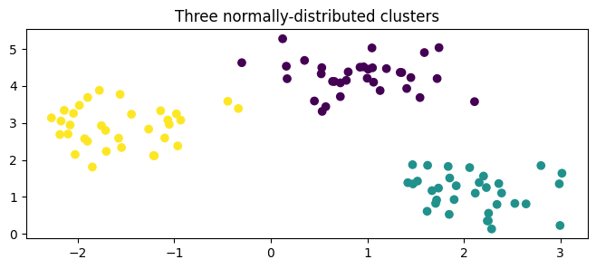

```python
import numpy             as np
import matplotlib.pyplot as plt
from sklearn.datasets import make_blobs

X, y = make_blobs(centers=3, cluster_std=0.5, random_state=0)
plt.figure(figsize=(8, 3))  # Set the figure size to 8 inches wide and 6 inches tall
plt.scatter(X[:, 0], X[:, 1], c=y)
plt.title("Three normally-distributed clusters")
plt.show()
```

[make_classification](https://scikit-learn.org/stable/modules/generated/sklearn.datasets.make_classification.html) also creates multiclass datasets but specializes in introducing noise by way of: correlated, redundant and uninformative features; multiple Gaussian clusters per class; and linear transformations of the feature space. Lets see a very simple example:

```
X, Y = make_classification(n_features=2, n_redundant=0, random_state=1, **param)
```

```python
from sklearn.datasets import make_classification

# Generate synthetic data
X, Y = make_classification(n_features=2, n_redundant=0, random_state=1, n_samples=10, n_classes=2)

print("X (Feature Matrix):\n", X)
print("Shape of X:", X.shape)
print("\nY (Target Vector):\n", Y)
print("Shape of Y:", Y.shape)
```

```
X (Feature Matrix):
 [[-1.52637437 -2.85961623]
 [-4.42287433  0.70896364]
 [-1.55118469  1.03584131]
 [-0.60483688 -2.00875146]
 [-3.42524143  1.49509867]
 [ 1.44634283 -1.14651383]
 [-1.60290743 -1.52320683]
 [ 0.78712117  0.55132541]
 [ 1.37496472 -0.22942496]
 [ 1.23169963  1.72073855]]
Shape of X: (10, 2)

Y (Target Vector):
 [0 1 1 0 1 0 0 1 0 1]
Shape of Y: (10,)
```

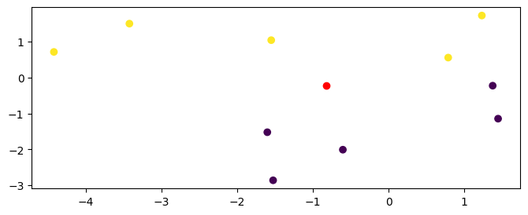

```python
plt.figure(figsize=(8,3))
plt.scatter(X[:, 0], X[:, 1], c=Y)
plt.scatter(mean[0], mean[1], c='r')
plt.show()
```

## References & Credits

To keep improving, view the [extensive tutorials](https://pandas.pydata.org/pandas-docs/stable/tutorials.html) offered by the official pandas docs, follow along with a few [Kaggle kernels](https://www.kaggle.com/kernels), and keep working on your own projects!